# Température *HadCRUT*

Dans ce document, c'est le package `prince` qui est utilisé pour réaliser l'ACP, pour démonstration.

```python
import pandas
import numpy
import matplotlib.pyplot as plt
import seaborn
seaborn.set_style("white")

from prince import PCA
```

```python
temp = pandas.read_table(
    "https://crudata.uea.ac.uk/cru/data/temperature/HadCRUT5.0Analysis_gl.txt",
    sep = "\s+",
    names = ["Jan", "Feb", "Mar", "Apr", "May", "Jun", "Jul", "Aug", "Sep", "Oct", "Nov", "Dec", "Annual"])
temp = temp.iloc[::2]
temp = temp.iloc[:-1] # suppression de la dernière ligne (i.e. 2024 n'est pas finie)
temp
```

|  | Jan | Feb | Mar | Apr | May | Jun | Jul | Aug | Sep | Oct | Nov | Dec | Annual |
| --- | --- | --- | --- | --- | --- | --- | --- | --- | --- | --- | --- | --- | --- |
| 1850 | -0.734 | -0.360 | -0.627 | -0.605 | -0.532 | -0.352 | -0.176 | -0.223 | -0.394 | -0.516 | -0.277 | -0.322 | -0.426 |
| 1851 | -0.266 | -0.467 | -0.641 | -0.528 | -0.222 | -0.207 | -0.136 | -0.148 | -0.146 | -0.045 | -0.108 | -0.248 | -0.264 |
| 1852 | -0.346 | -0.496 | -0.567 | -0.575 | -0.113 | -0.077 | 0.009 | -0.149 | -0.006 | -0.158 | -0.275 | 0.064 | -0.224 |
| 1853 | -0.204 | -0.399 | -0.273 | -0.401 | -0.270 | -0.124 | -0.072 | -0.040 | -0.266 | -0.373 | -0.401 | -0.326 | -0.262 |
| 1854 | -0.403 | -0.392 | -0.247 | -0.327 | -0.277 | -0.302 | -0.162 | -0.233 | -0.216 | -0.099 | -0.412 | -0.454 | -0.294 |
| ... | ... | ... | ... | ... | ... | ... | ... | ... | ... | ... | ... | ... | ... |
| 2020 | 1.058 | 1.110 | 1.075 | 1.050 | 0.894 | 0.811 | 0.822 | 0.809 | 0.867 | 0.799 | 1.007 | 0.692 | 0.916 |
| 2021 | 0.707 | 0.565 | 0.737 | 0.757 | 0.698 | 0.718 | 0.791 | 0.809 | 0.875 | 0.928 | 0.864 | 0.758 | 0.767 |
| 2022 | 0.782 | 0.753 | 0.890 | 0.767 | 0.750 | 0.847 | 0.778 | 0.875 | 0.816 | 0.951 | 0.669 | 0.745 | 0.802 |
| 2023 | 0.783 | 0.886 | 1.129 | 0.925 | 0.880 | 1.059 | 1.161 | 1.213 | 1.348 | 1.327 | 1.342 | 1.264 | 1.110 |
| 2024 | 1.146 | 1.276 | 1.221 | 1.207 | 1.061 | 1.094 | 1.130 | 1.216 | 1.143 | 1.201 | 1.209 | 1.125 | 1.169 |

175 rows × 13 columns

## Description

- Pas de données manquantes
- Des moyennes globalement similaires
- Idem pour la variance
- Pas de distribution dissymétrique, mais quelques valeurs extrêmes toutefois.

```python
temp.describe().round(2)
```

|  | Jan | Feb | Mar | Apr | May | Jun | Jul | Aug | Sep | Oct | Nov | Dec | Annual |
| --- | --- | --- | --- | --- | --- | --- | --- | --- | --- | --- | --- | --- | --- |
| count | 175.00 | 175.00 | 175.00 | 175.00 | 175.00 | 175.00 | 175.00 | 175.00 | 175.00 | 175.00 | 175.00 | 175.00 | 175.00 |
| mean | -0.09 | -0.09 | -0.11 | -0.08 | -0.08 | -0.06 | -0.03 | -0.02 | -0.04 | -0.03 | -0.07 | -0.10 | -0.07 |
| std | 0.43 | 0.44 | 0.46 | 0.42 | 0.39 | 0.37 | 0.36 | 0.37 | 0.37 | 0.40 | 0.42 | 0.43 | 0.39 |
| min | -1.04 | -0.85 | -0.83 | -0.68 | -0.70 | -0.63 | -0.59 | -0.61 | -0.65 | -0.68 | -0.68 | -0.90 | -0.60 |
| 25% | -0.39 | -0.41 | -0.42 | -0.40 | -0.35 | -0.30 | -0.30 | -0.28 | -0.31 | -0.33 | -0.37 | -0.41 | -0.34 |
| 50% | -0.18 | -0.21 | -0.20 | -0.18 | -0.18 | -0.15 | -0.12 | -0.12 | -0.14 | -0.10 | -0.13 | -0.20 | -0.17 |
| 75% | 0.15 | 0.13 | 0.12 | 0.15 | 0.13 | 0.11 | 0.10 | 0.14 | 0.13 | 0.12 | 0.08 | 0.11 | 0.09 |
| max | 1.15 | 1.28 | 1.22 | 1.21 | 1.06 | 1.09 | 1.16 | 1.22 | 1.35 | 1.33 | 1.34 | 1.26 | 1.17 |

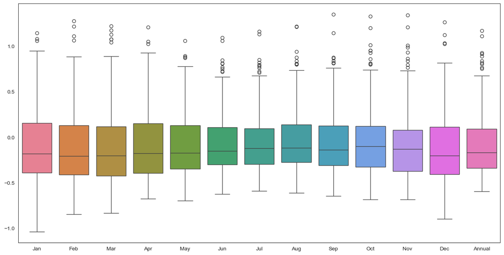

```python
plt.figure(figsize = (16, 8))
seaborn.boxplot(data = temp)
plt.show()
```

## Evolution annuelle sur la période

La représentation de l'évolution des anomalies moyennes annuelles permet de voir que la température est en augmentation, particulièrement depuis le milieu des années 1970.

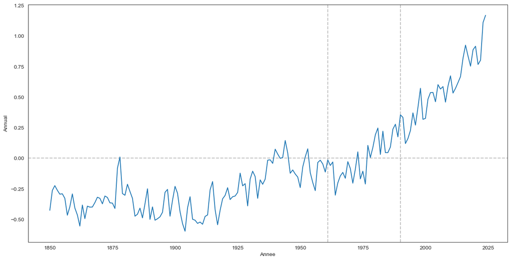

```python
plt.figure(figsize = (16, 8))
plt.axhline(y = 0, linestyle = "dashed", color = "gray", alpha = .5)
plt.axvline(x = 1961, linestyle = "dashed", color = "gray", alpha = .5)
plt.axvline(x = 1990, linestyle = "dashed", color = "gray", alpha = .5)
seaborn.lineplot(x = "Annee", y = "Annual",
                 data = temp.assign(Annee = temp.index).reset_index(drop=True))
plt.show()
```

## Analyse

on enlève la dernière colonne, qui est l'anomalie annuelle.

```python
temp2 = temp[temp.columns[:12]]
temp2
```

|  | Jan | Feb | Mar | Apr | May | Jun | Jul | Aug | Sep | Oct | Nov | Dec |
| --- | --- | --- | --- | --- | --- | --- | --- | --- | --- | --- | --- | --- |
| 1850 | -0.734 | -0.360 | -0.627 | -0.605 | -0.532 | -0.352 | -0.176 | -0.223 | -0.394 | -0.516 | -0.277 | -0.322 |
| 1851 | -0.266 | -0.467 | -0.641 | -0.528 | -0.222 | -0.207 | -0.136 | -0.148 | -0.146 | -0.045 | -0.108 | -0.248 |
| 1852 | -0.346 | -0.496 | -0.567 | -0.575 | -0.113 | -0.077 | 0.009 | -0.149 | -0.006 | -0.158 | -0.275 | 0.064 |
| 1853 | -0.204 | -0.399 | -0.273 | -0.401 | -0.270 | -0.124 | -0.072 | -0.040 | -0.266 | -0.373 | -0.401 | -0.326 |
| 1854 | -0.403 | -0.392 | -0.247 | -0.327 | -0.277 | -0.302 | -0.162 | -0.233 | -0.216 | -0.099 | -0.412 | -0.454 |
| ... | ... | ... | ... | ... | ... | ... | ... | ... | ... | ... | ... | ... |
| 2020 | 1.058 | 1.110 | 1.075 | 1.050 | 0.894 | 0.811 | 0.822 | 0.809 | 0.867 | 0.799 | 1.007 | 0.692 |
| 2021 | 0.707 | 0.565 | 0.737 | 0.757 | 0.698 | 0.718 | 0.791 | 0.809 | 0.875 | 0.928 | 0.864 | 0.758 |
| 2022 | 0.782 | 0.753 | 0.890 | 0.767 | 0.750 | 0.847 | 0.778 | 0.875 | 0.816 | 0.951 | 0.669 | 0.745 |
| 2023 | 0.783 | 0.886 | 1.129 | 0.925 | 0.880 | 1.059 | 1.161 | 1.213 | 1.348 | 1.327 | 1.342 | 1.264 |
| 2024 | 1.146 | 1.276 | 1.221 | 1.207 | 1.061 | 1.094 | 1.130 | 1.216 | 1.143 | 1.201 | 1.209 | 1.125 |

175 rows × 12 columns

```python
pca = PCA(n_components = 12)
pca.fit(temp2)
```

```
PCA(n_components=12)
```

On remarque que 92% de l'information est contenue dans le seul premier facteur.

```python
pca.eigenvalues_summary
```

| component | eigenvalue | % of variance | % of variance (cumulative) |
| --- | --- | --- | --- |
| 0 | 11.124 | 92.70% | 92.70% |
| 1 | 0.301 | 2.51% | 95.21% |
| 2 | 0.126 | 1.05% | 96.26% |
| 3 | 0.103 | 0.85% | 97.12% |
| 4 | 0.083 | 0.69% | 97.81% |
| 5 | 0.065 | 0.54% | 98.35% |
| 6 | 0.047 | 0.39% | 98.74% |
| 7 | 0.041 | 0.35% | 99.08% |
| 8 | 0.035 | 0.29% | 99.38% |
| 9 | 0.029 | 0.24% | 99.61% |
| 10 | 0.024 | 0.20% | 99.82% |
| 11 | 0.022 | 0.18% | 100.00% |

```python
pca.scree_plot()
```

[interactive chart not shown]

```python
pca.column_correlations.round(2)
```

| component variable | 0 | 1 | 2 | 3 | 4 | 5 | 6 | 7 | 8 | 9 | 10 | 11 |
| --- | --- | --- | --- | --- | --- | --- | --- | --- | --- | --- | --- | --- |
| Jan | 0.94 | -0.26 | -0.15 | 0.13 | 0.01 | -0.11 | -0.08 | 0.05 | -0.00 | -0.00 | -0.01 | -0.01 |
| Feb | 0.94 | -0.26 | -0.11 | 0.01 | 0.00 | 0.16 | 0.07 | -0.04 | -0.02 | 0.00 | 0.02 | -0.00 |
| Mar | 0.96 | -0.14 | 0.08 | -0.20 | -0.07 | 0.01 | -0.09 | 0.06 | -0.02 | -0.01 | 0.05 | -0.00 |
| Apr | 0.97 | -0.13 | 0.08 | -0.08 | -0.03 | -0.03 | 0.02 | -0.04 | 0.04 | 0.02 | -0.12 | 0.03 |
| May | 0.97 | -0.07 | 0.08 | -0.01 | 0.05 | -0.13 | 0.08 | -0.07 | 0.03 | 0.02 | 0.07 | -0.02 |
| Jun | 0.98 | 0.03 | 0.11 | 0.04 | 0.12 | 0.00 | 0.05 | 0.06 | -0.06 | -0.10 | -0.01 | 0.03 |
| Jul | 0.97 | 0.07 | 0.12 | 0.07 | 0.08 | 0.05 | -0.03 | 0.04 | -0.04 | 0.12 | -0.00 | -0.01 |
| Aug | 0.98 | 0.09 | 0.07 | 0.08 | -0.01 | 0.07 | -0.05 | -0.01 | 0.09 | -0.05 | -0.01 | -0.08 |
| Sep | 0.98 | 0.12 | 0.01 | 0.10 | -0.08 | 0.02 | -0.04 | -0.03 | 0.05 | -0.01 | 0.04 | 0.11 |
| Oct | 0.97 | 0.15 | -0.03 | 0.02 | -0.12 | -0.03 | -0.01 | -0.08 | -0.12 | -0.01 | -0.02 | -0.03 |
| Nov | 0.96 | 0.18 | -0.11 | -0.03 | -0.09 | -0.02 | 0.10 | 0.11 | 0.03 | 0.03 | -0.00 | -0.01 |
| Dec | 0.94 | 0.21 | -0.17 | -0.12 | 0.15 | -0.00 | -0.05 | -0.04 | 0.02 | -0.00 | -0.01 | 0.01 |

Le cercle des corrélations nous informe que les mois ont globalement tous le même comportement, et donc que les années à droite du graphique seront les années les plus chaudes.

> Vous remarquerez qu'il est plus simple à obtenir avec le module `prince`, par rapport à `sklearn`.

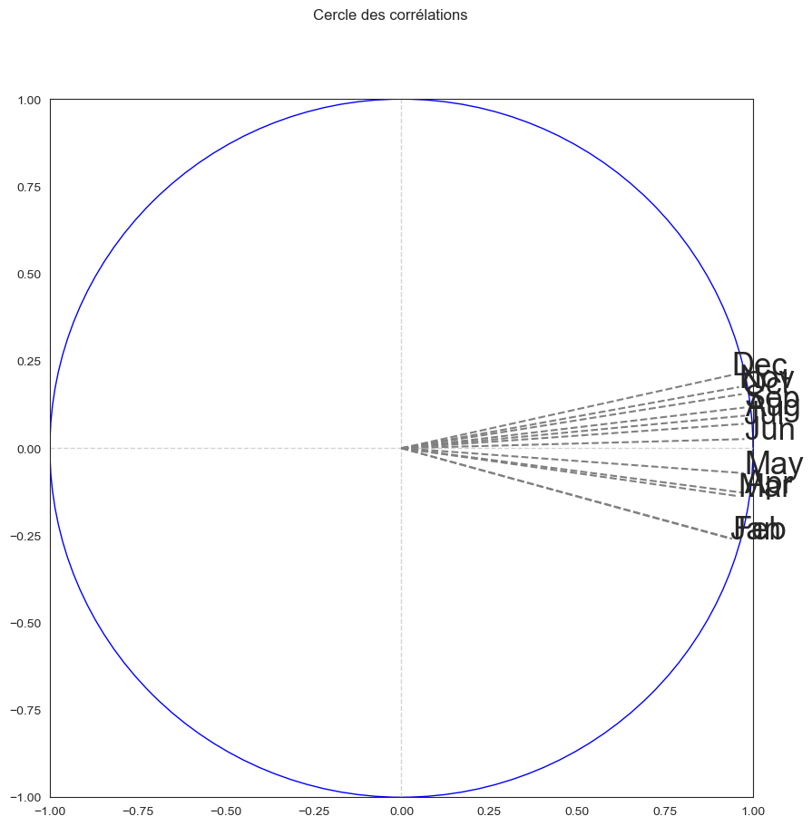

```python
coord_col = pca.column_correlations

fig, axes = plt.subplots(figsize = (10, 10))
fig.suptitle("Cercle des corrélations")
axes.set_xlim(-1, 1)
axes.set_ylim(-1, 1)
axes.axvline(x = 0, color = 'lightgray', linestyle = '--', linewidth = 1)
axes.axhline(y = 0, color = 'lightgray', linestyle = '--', linewidth = 1)
for j in range(12):
    xj = coord_col.iloc[j,0]
    yj = coord_col.iloc[j,1]
    axes.text(xj, yj, coord_col.index[j], size = 25)
    axes.plot([0,xj], [0,yj], color = "gray", linestyle = 'dashed')
plt.gca().add_artist(plt.Circle((0,0),1,color='blue',fill=False))

plt.show()
```

```python
pca.plot(temp2,
         x_component = 0,
         y_component = 1,
         show_column_markers = False,
         show_column_labels = True)
```

[interactive chart not shown]

```python
coord = pca.row_coordinates(temp2)
coord
```

| component | 0 | 1 | 2 | 3 | 4 | 5 | 6 | 7 | 8 | 9 | 10 | 11 |
| --- | --- | --- | --- | --- | --- | --- | --- | --- | --- | --- | --- | --- |
| 1850 | -3.071309 | 0.635555 | -0.018651 | 0.009371 | 0.413547 | 0.786137 | 0.277005 | 0.275376 | 0.211260 | 0.246231 | 0.110715 | -0.175821 |
| 1851 | -1.640291 | 0.837327 | -0.257089 | 0.681652 | 0.027104 | -0.296712 | 0.175586 | 0.023327 | -0.190173 | 0.062788 | 0.182531 | -0.199253 |
| 1852 | -1.275256 | 1.124770 | -0.045102 | 0.519288 | 0.834015 | -0.211089 | -0.124049 | -0.187674 | -0.106376 | 0.099260 | 0.530889 | 0.202568 |
| 1853 | -1.656835 | -0.075961 | 0.401136 | 0.294911 | 0.491537 | 0.061327 | -0.393613 | 0.325093 | 0.116623 | -0.098832 | 0.172356 | -0.257820 |
| 1854 | -1.938869 | 0.038687 | 0.406090 | -0.009249 | -0.294111 | -0.008112 | -0.217234 | -0.209801 | -0.323525 | 0.125962 | 0.132320 | -0.056110 |
| ... | ... | ... | ... | ... | ... | ... | ... | ... | ... | ... | ... | ... |
| 2020 | 8.429555 | -0.726340 | -0.004645 | 0.009049 | -0.256703 | -0.012315 | 0.232039 | 0.268562 | 0.148746 | 0.157750 | -0.010115 | 0.140896 |
| 2021 | 7.230910 | 0.684227 | 0.178344 | 0.265253 | -0.218412 | -0.195664 | -0.144415 | 0.004509 | -0.046591 | 0.065496 | -0.051645 | 0.080758 |
| 2022 | 7.514924 | 0.156719 | 0.358792 | 0.210943 | 0.014276 | 0.013955 | -0.273364 | -0.163086 | -0.275042 | -0.290296 | 0.061668 | -0.064923 |
| 2023 | 10.213719 | 1.621144 | 0.146847 | 0.195253 | -0.293477 | 0.346207 | -0.231632 | 0.111659 | -0.056894 | -0.000021 | 0.202233 | 0.227505 |
| 2024 | 10.660062 | 0.095211 | 0.089687 | 0.192368 | -0.050481 | 0.263344 | 0.012659 | -0.005632 | 0.036619 | -0.000161 | -0.079894 | -0.071410 |

175 rows × 12 columns

```python
contrib = pca.row_contributions_
contrib.round(2)
```

| component | 0 | 1 | 2 | 3 | 4 | 5 | 6 | 7 | 8 | 9 | 10 | 11 |
| --- | --- | --- | --- | --- | --- | --- | --- | --- | --- | --- | --- | --- |
| 1850 | 0.00 | 0.01 | 0.00 | 0.00 | 0.01 | 0.05 | 0.01 | 0.01 | 0.01 | 0.01 | 0.00 | 0.01 |
| 1851 | 0.00 | 0.01 | 0.00 | 0.03 | 0.00 | 0.01 | 0.00 | 0.00 | 0.01 | 0.00 | 0.01 | 0.01 |
| 1852 | 0.00 | 0.02 | 0.00 | 0.02 | 0.05 | 0.00 | 0.00 | 0.00 | 0.00 | 0.00 | 0.07 | 0.01 |
| 1853 | 0.00 | 0.00 | 0.01 | 0.00 | 0.02 | 0.00 | 0.02 | 0.01 | 0.00 | 0.00 | 0.01 | 0.02 |
| 1854 | 0.00 | 0.00 | 0.01 | 0.00 | 0.01 | 0.00 | 0.01 | 0.01 | 0.02 | 0.00 | 0.00 | 0.00 |
| ... | ... | ... | ... | ... | ... | ... | ... | ... | ... | ... | ... | ... |
| 2020 | 0.04 | 0.01 | 0.00 | 0.00 | 0.00 | 0.00 | 0.01 | 0.01 | 0.00 | 0.00 | 0.00 | 0.01 |
| 2021 | 0.03 | 0.01 | 0.00 | 0.00 | 0.00 | 0.00 | 0.00 | 0.00 | 0.00 | 0.00 | 0.00 | 0.00 |
| 2022 | 0.03 | 0.00 | 0.01 | 0.00 | 0.00 | 0.00 | 0.01 | 0.00 | 0.01 | 0.02 | 0.00 | 0.00 |
| 2023 | 0.05 | 0.05 | 0.00 | 0.00 | 0.01 | 0.01 | 0.01 | 0.00 | 0.00 | 0.00 | 0.01 | 0.01 |
| 2024 | 0.06 | 0.00 | 0.00 | 0.00 | 0.00 | 0.01 | 0.00 | 0.00 | 0.00 | 0.00 | 0.00 | 0.00 |

175 rows × 12 columns

## Représentation des années

On peut maintenant representer les années sur le premier plan factoriel. On voit bien que les dernières années sont les plus chaudes.

```python
pca.plot(temp2,
         x_component = 0,
         y_component = 1,
         show_row_markers = False,
         show_column_markers = False,
         show_row_labels = True)
```

[interactive chart not shown]

En se concentrant sur les valeurs extrêmes.

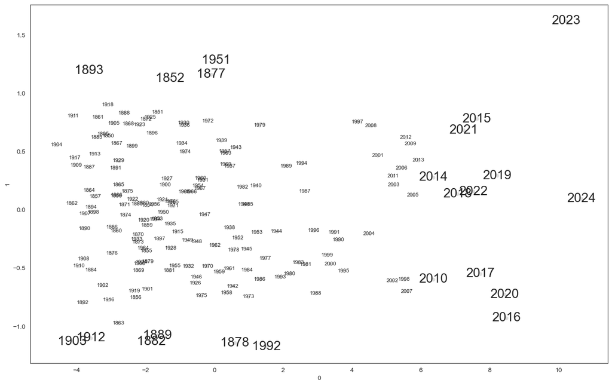

```python
plt.figure(figsize = (16, 10))
seaborn.scatterplot(x = 0, y = 1, data = coord, color = "gray", alpha = .25)
for i in range(coord.shape[0]):
    taille = "small"
    if (contrib.iloc[i,0] > .02):
        taille = 20
    if (contrib.iloc[i,1] > .02):
        taille = 20
    plt.text(coord.iloc[i][0], coord.iloc[i][1], coord.index[i],
             fontsize = taille, ha = "center", va = "center")
```

```python
pandas.DataFrame(temp.mean()).transpose().round(3).rename(index = {0: "Moyenne"})
```

|  | Jan | Feb | Mar | Apr | May | Jun | Jul | Aug | Sep | Oct | Nov | Dec | Annual |
| --- | --- | --- | --- | --- | --- | --- | --- | --- | --- | --- | --- | --- | --- |
| Moyenne | -0.092 | -0.089 | -0.109 | -0.079 | -0.083 | -0.056 | -0.034 | -0.017 | -0.035 | -0.031 | -0.068 | -0.102 | -0.066 |

```python
temp.filter(items = [1852, 1877, 1893, 1951], axis = 0)
```

|  | Jan | Feb | Mar | Apr | May | Jun | Jul | Aug | Sep | Oct | Nov | Dec | Annual |
| --- | --- | --- | --- | --- | --- | --- | --- | --- | --- | --- | --- | --- | --- |
| 1852 | -0.346 | -0.496 | -0.567 | -0.575 | -0.113 | -0.077 | 0.009 | -0.149 | -0.006 | -0.158 | -0.275 | 0.064 | -0.224 |
| 1877 | -0.409 | -0.195 | -0.070 | -0.316 | -0.403 | -0.109 | 0.017 | 0.230 | 0.127 | 0.125 | 0.043 | -0.028 | -0.082 |
| 1893 | -1.040 | -0.846 | -0.421 | -0.508 | -0.570 | -0.453 | -0.253 | -0.295 | -0.369 | -0.305 | -0.402 | -0.477 | -0.495 |
| 1951 | -0.373 | -0.521 | -0.276 | -0.120 | 0.020 | 0.050 | 0.027 | 0.111 | 0.121 | 0.116 | -0.082 | 0.066 | -0.072 |

```python
temp.filter(items = [1878, 1882, 1903, 1912, 1992], axis = 0)
```

|  | Jan | Feb | Mar | Apr | May | Jun | Jul | Aug | Sep | Oct | Nov | Dec | Annual |
| --- | --- | --- | --- | --- | --- | --- | --- | --- | --- | --- | --- | --- | --- |
| 1878 | -0.041 | 0.261 | 0.403 | 0.210 | -0.092 | 0.018 | -0.062 | -0.045 | 0.028 | -0.148 | -0.119 | -0.290 | 0.010 |
| 1882 | -0.012 | -0.098 | -0.146 | -0.289 | -0.290 | -0.358 | -0.308 | -0.224 | -0.145 | -0.382 | -0.385 | -0.628 | -0.272 |
| 1903 | -0.423 | -0.235 | -0.406 | -0.590 | -0.514 | -0.549 | -0.511 | -0.611 | -0.571 | -0.674 | -0.631 | -0.708 | -0.535 |
| 1912 | -0.326 | -0.312 | -0.557 | -0.338 | -0.335 | -0.290 | -0.510 | -0.580 | -0.646 | -0.685 | -0.556 | -0.577 | -0.476 |
| 1992 | 0.357 | 0.343 | 0.305 | 0.156 | 0.164 | 0.152 | 0.003 | 0.035 | -0.096 | -0.029 | -0.040 | 0.090 | 0.120 |

### Années (beaucoup) plus chaudes que la moyenne

```python
temp.filter(items = [i for i in range(2015, 2022)], axis = 0)
```

|  | Jan | Feb | Mar | Apr | May | Jun | Jul | Aug | Sep | Oct | Nov | Dec | Annual |
| --- | --- | --- | --- | --- | --- | --- | --- | --- | --- | --- | --- | --- | --- |
| 2015 | 0.732 | 0.773 | 0.787 | 0.684 | 0.726 | 0.752 | 0.710 | 0.799 | 0.818 | 1.014 | 0.985 | 1.035 | 0.818 |
| 2016 | 1.079 | 1.216 | 1.176 | 1.023 | 0.873 | 0.769 | 0.761 | 0.940 | 0.837 | 0.812 | 0.839 | 0.772 | 0.925 |
| 2017 | 0.947 | 1.062 | 1.044 | 0.835 | 0.775 | 0.650 | 0.793 | 0.802 | 0.723 | 0.804 | 0.795 | 0.806 | 0.836 |
| 2018 | 0.707 | 0.776 | 0.776 | 0.811 | 0.701 | 0.727 | 0.724 | 0.734 | 0.677 | 0.858 | 0.732 | 0.816 | 0.753 |
| 2019 | 0.813 | 0.835 | 1.077 | 0.925 | 0.777 | 0.808 | 0.851 | 0.836 | 0.813 | 0.954 | 0.933 | 1.026 | 0.887 |
| 2020 | 1.058 | 1.110 | 1.075 | 1.050 | 0.894 | 0.811 | 0.822 | 0.809 | 0.867 | 0.799 | 1.007 | 0.692 | 0.916 |
| 2021 | 0.707 | 0.565 | 0.737 | 0.757 | 0.698 | 0.718 | 0.791 | 0.809 | 0.875 | 0.928 | 0.864 | 0.758 | 0.767 |

## Heatmap classique de l'évolution pour repérer les années à comportement atypique

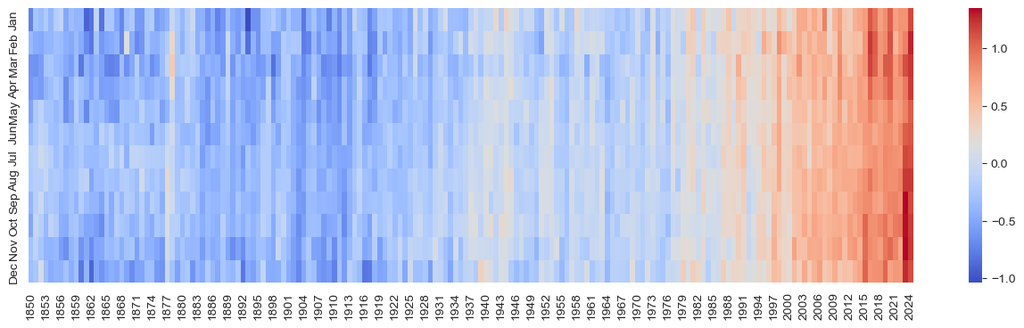

```python
plt.figure(figsize = (16, 4))
g = seaborn.heatmap(temp2.T, cmap = "coolwarm")
```

## Et avec une AFC ?

Les données doivent être toutes positives, donc on ajoute une valeur fixe à toutes les valeurs.

```python
from prince import CA

ca = CA()
ca.fit(temp2 + 10)
```

```
<prince.ca.CA at 0x1a6b43edd30>
```

Certaines années ont un comportement très particulier, ce qui gène considérablement l'analyse globale. Vous pouvez *zoomer* dans le graphique obtenu.

```python
ca.plot(temp2,
        x_component = 0,
        y_component = 1,
        show_row_markers = False,
        show_column_markers = False,
        show_row_labels = True,
        show_column_labels = False
)
```

[interactive chart not shown]

```python
ca.plot(temp2,
        x_component = 0,
        y_component = 1,
        show_row_markers = False,
        show_column_markers = False,
        show_row_labels = False,
        show_column_labels = True
)
```

[interactive chart not shown]

La représentation conjointe ne nous permet pas de mieux commprendre les comportements atypiques.

```python
ca.plot(temp2,
        x_component = 0,
        y_component = 1,
        show_row_markers = False,
        show_column_markers = False,
        show_row_labels = True,
        show_column_labels = True
)
```

[interactive chart not shown]

Quelques remarques par année :

- *1878* : Mars très chaud
- *1942* : Janvier très chaud alors que l'année semble froide ou moyenne
- *1943* : Janvier et Mars froid
- *1961* : Décembre très froid
- *1978* : Août très froid

```python
temp.filter(items = [i for i in [1878, 1942, 1943, 1961, 1978]], axis = 0)
```

|  | Jan | Feb | Mar | Apr | May | Jun | Jul | Aug | Sep | Oct | Nov | Dec | Annual |
| --- | --- | --- | --- | --- | --- | --- | --- | --- | --- | --- | --- | --- | --- |
| 1878 | -0.041 | 0.261 | 0.403 | 0.210 | -0.092 | 0.018 | -0.062 | -0.045 | 0.028 | -0.148 | -0.119 | -0.290 | 0.010 |
| 1942 | 0.250 | 0.016 | -0.045 | -0.009 | 0.122 | 0.027 | -0.062 | -0.061 | -0.014 | -0.093 | -0.056 | -0.080 | -0.001 |
| 1943 | -0.191 | -0.027 | -0.164 | 0.022 | 0.033 | -0.078 | 0.021 | 0.031 | -0.015 | 0.230 | 0.104 | 0.110 | 0.006 |
| 1961 | -0.046 | 0.097 | -0.055 | 0.066 | 0.074 | 0.092 | -0.033 | -0.008 | -0.025 | -0.060 | -0.027 | -0.248 | -0.014 |
| 1978 | 0.037 | 0.075 | 0.060 | 0.053 | 0.014 | -0.054 | 0.015 | -0.217 | 0.037 | -0.060 | 0.094 | 0.011 | 0.006 |

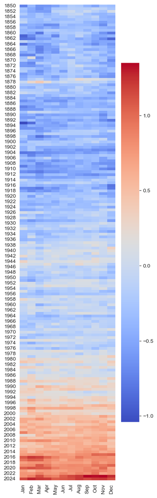

```python
plt.figure(figsize = (4, 16))
g = seaborn.heatmap(temp2, cmap = "coolwarm")
```